# Post Lab 1 Practice

Author

Nathaniel Grimes

# Post-Lab Practice

Create a new repository in your GitHub account. Clone this into R Studio (no need to fork, it’s already in your account).

In this new repository, create a new Quarto document and set it up:

- Code folding (either `true` (fold, but hide it) or `show` (fold, but show it))
- Echo code to the document, but suppress warnings and messages

Delete the template text, and create a new code chunk. Attach the `tidyverse` package. Attach the `gapminder` package (install it if you need to!).

```r
library(tidyverse)
library(gapminder)
```

## Wrangling Practice

1. Examine the `relig_income` data. Is it tidy? Which of these functions would you use to help you make it tidy?
1. `mutate()`
2. `separate()`
3. `pivot_longer()`
4. `select()`
2. Use the function you selected in question 1 to make `relig_income` tidy
3. What does the following code do?

```r
lizard_clean<-lizard %>%
  select(spp,sex,SV_length,weight) %>%
  filter(sex!="J") %>%
  drop_na() %>%
  group_by(spp,sex) %>%
  filter(n()>=6)
```

## Analysis Work:

Use the `gapminder` life expectancy data from `gapminder` package (install if needed).

```r
# Load data
df <- gapminder
head(df)
```

```
# A tibble: 6 × 6
  country     continent  year lifeExp      pop gdpPercap
  <fct>       <fct>     <int>   <dbl>    <int>     <dbl>
1 Afghanistan Asia       1952    28.8  8425333      779.
2 Afghanistan Asia       1957    30.3  9240934      821.
3 Afghanistan Asia       1962    32.0 10267083      853.
4 Afghanistan Asia       1967    34.0 11537966      836.
5 Afghanistan Asia       1972    36.1 13079460      740.
6 Afghanistan Asia       1977    38.4 14880372      786.
```

Conduct an analysis on whether life expectancy is increasing over time.

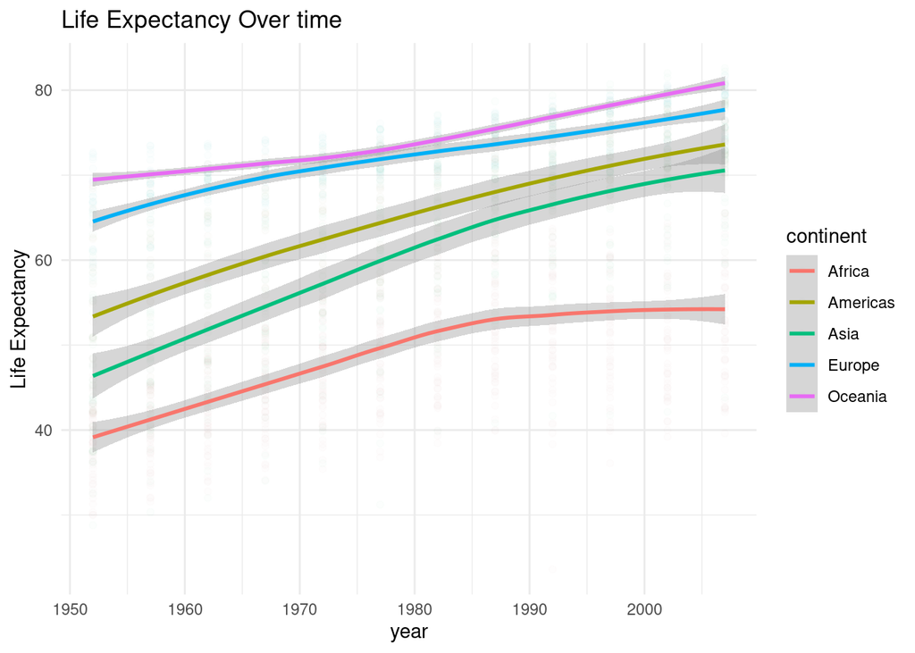

```r
# visualize life expectance over time
df %>%
  ggplot(aes(x=year, y=lifeExp, color=continent)) +
  geom_point(alpha=0.01)+
  geom_smooth()+
  theme_minimal()+
  labs(
    title="Life Expectancy Over time",
    x='year',
    y='Life Expectancy'

  )
```

Run a linear regression on the data with `gdpPercap` and `continent` as covariates.

```r
model1 <- lm(lifeExp ~ gdpPercap + continent, data = df)
summary(model1)
```

```
Call:
lm(formula = lifeExp ~ gdpPercap + continent, data = df)

Residuals:
    Min      1Q  Median      3Q     Max
-49.241  -4.479   0.347   5.105  25.138

Coefficients:
                   Estimate Std. Error t value Pr(>|t|)
(Intercept)       4.789e+01  3.398e-01  140.93   <2e-16 ***
gdpPercap         4.453e-04  2.350e-05   18.95   <2e-16 ***
continentAmericas 1.359e+01  6.008e-01   22.62   <2e-16 ***
continentAsia     8.658e+00  5.555e-01   15.59   <2e-16 ***
continentEurope   1.757e+01  6.257e-01   28.08   <2e-16 ***
continentOceania  1.815e+01  1.787e+00   10.15   <2e-16 ***
---
Signif. codes:  0 '***' 0.001 '**' 0.01 '*' 0.05 '.' 0.1 ' ' 1

Residual standard error: 8.39 on 1698 degrees of freedom
Multiple R-squared:  0.5793,    Adjusted R-squared:  0.5781
F-statistic: 467.7 on 5 and 1698 DF,  p-value: < 2.2e-16
```

```r
model2 <- lm(lifeExp ~ log(gdpPercap) + continent, data=df)
summary(model2)
```

```
Call:
lm(formula = lifeExp ~ log(gdpPercap) + continent, data = df)

Residuals:
     Min       1Q   Median       3Q      Max
-27.1163  -3.4739   0.4336   4.3519  18.5632

Coefficients:
                  Estimate Std. Error t value Pr(>|t|)
(Intercept)         2.3170     1.3594   1.704   0.0885 .
log(gdpPercap)      6.4220     0.1835  35.003  < 2e-16 ***
continentAmericas   7.0147     0.5544  12.652  < 2e-16 ***
continentAsia       5.9117     0.4768  12.400  < 2e-16 ***
continentEurope     9.5771     0.6041  15.855  < 2e-16 ***
continentOceania    9.2135     1.5359   5.999 2.42e-09 ***
---
Signif. codes:  0 '***' 0.001 '**' 0.01 '*' 0.05 '.' 0.1 ' ' 1

Residual standard error: 7.038 on 1698 degrees of freedom
Multiple R-squared:  0.704, Adjusted R-squared:  0.7031
F-statistic: 807.6 on 5 and 1698 DF,  p-value: < 2.2e-16
```

Plot the observed trends however you see fit.

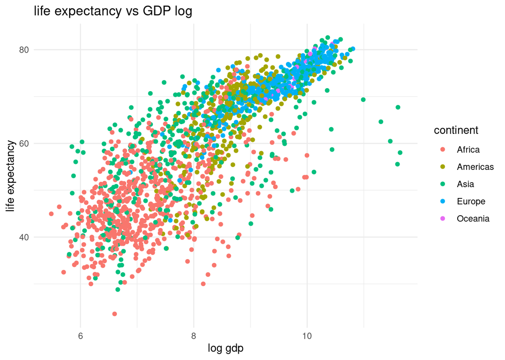

```r
# plot GDP and life expectancy
df %>% ggplot(
  aes(x=log(gdpPercap), y = lifeExp, color = continent)) +
  geom_point()+
  theme_minimal()+
  labs(
    title='life expectancy vs GDP log',
    x='log gdp',
    y='life expectancy'
  )
```

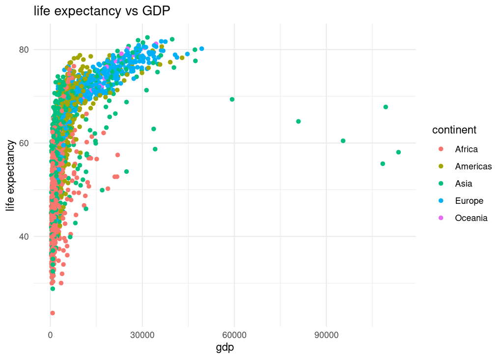

```r
df %>% ggplot(
  aes(x=gdpPercap, y = lifeExp, color = continent)) +
  geom_point()+
  theme_minimal()+
  labs(
    title='life expectancy vs GDP',
    x='gdp',
    y='life expectancy'
  )
```

[output not shown]